# Module 4 - Multiple Linear Regression

## Data and Description

*Note: The majority of the code needed below can be found in the example files from lecture, replacing the variable names with those you create for this data set. You may also want to draw on your code from the in-class coding exercise from Module 2 for diagnostics.*

Companies are continually evaluating supervisors to, not only determine adequate performance, but also gauge employee morale (an important indicator for employee productivity). In an effort to understand the important aspects of a good supervisor, employees at a certain company were asked to provide an overall rating and scores on 6 characteristics of their immediate managers (30 in total). Employees were asked to rate the following statements on a scale from 0 to 100 (0 meaning ”completely disagree” to 100 meaning ”completely agree”):

| Variable | Description |
| --- | --- |
| Rating | Overall rating of supervisor performance. Higher score means better supervisor. |
| complaints | Score for “Your supervisor handles employee complaints appropriately.” |
| Privileges | Score for “Your supervisor allows special privileges.” |
| Learn | Score for “Your supervisor provides opportunities to learn new things.” |
| Raises | Score for “Your supervisor bases raises on performance.” |
| Critical | Score for “Your supervisor is too critical of poor performance.” |
| Advance | Score for “I am *not* satisfied with the rate I am advancing in the company.” |

Do the following:

1. Download the “Supervisor.txt” file from Canvas and put it in the same folder as this R Markdown file.
2. Read in the data set, call it “super”, and take a look at the top few rows.

```r
super <- read.csv("Supervisor.txt", header = TRUE, sep = " ")
head(super)
```

```
##   Rating Complaints Privileges Learn Raises Critical Advance
## 1     43         51         30    39     61       92      45
## 2     63         64         51    54     63       73      47
## 3     71         70         68    69     76       86      48
## 4     61         63         45    47     54       84      35
## 5     81         78         56    66     71       83      47
## 6     43         55         49    44     54       49      34
```

## Explore the Data

### Create a Scatterplot Matrix. Do you observe any variables that appear strongly linearly correlated?

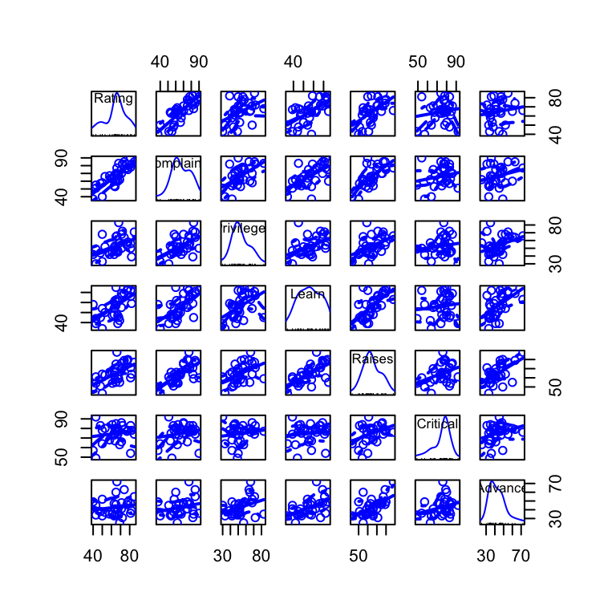

```r
scatterplotMatrix(super)
```

### Create a Correlation Matrix. Do the correlations here match you insights obtained from the scatterplot matrix?

```r
# cov(super)  # covariance
round(cor(super), 2)  # correlation
```

```
##            Rating Complaints Privileges Learn Raises Critical Advance
## Rating       1.00       0.83       0.43  0.62   0.59     0.16    0.16
## Complaints   0.83       1.00       0.56  0.60   0.67     0.19    0.22
## Privileges   0.43       0.56       1.00  0.49   0.45     0.15    0.34
## Learn        0.62       0.60       0.49  1.00   0.64     0.12    0.53
## Raises       0.59       0.67       0.45  0.64   1.00     0.38    0.57
## Critical     0.16       0.19       0.15  0.12   0.38     1.00    0.28
## Advance      0.16       0.22       0.34  0.53   0.57     0.28    1.00
```

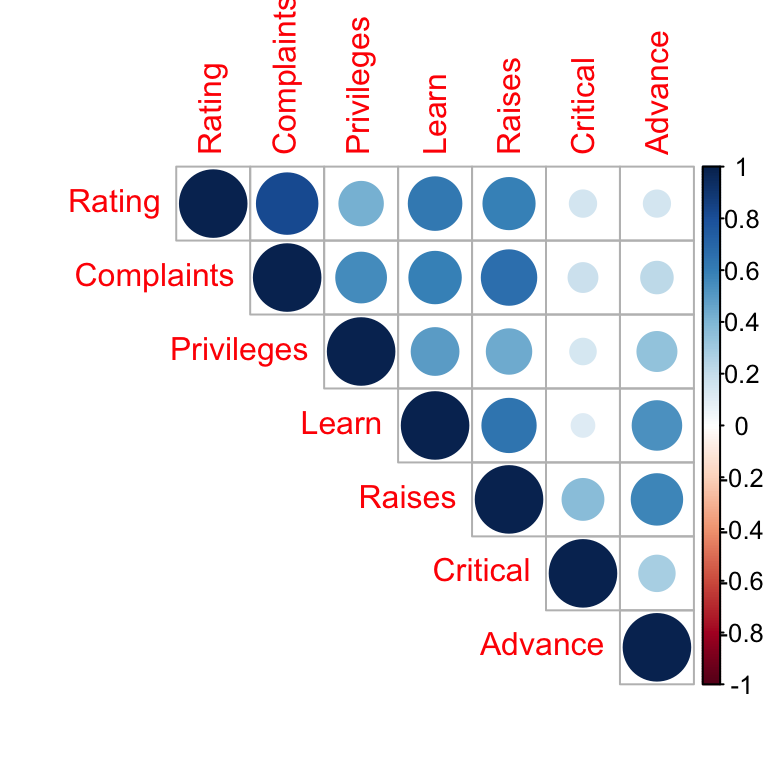

```r
corrplot(cor(super), type = "upper")
```

## Fit a Multiple Linear Regression Model with `Ratings` as the response and all other variables as predictors. Call the fitted model `super.lm`.

Make sure to save the residuals and fitted values to your `super` data frame.

```r
# super.lm <- lm(Rating ~ Complaints + Privileges + Learn +
#                  Raises + Critical + Advance, data = super)
super.lm <- lm(Rating ~ ., data = super)
summary(super.lm)
```

```
##
## Call:
## lm(formula = Rating ~ ., data = super)
##
## Residuals:
##      Min       1Q   Median       3Q      Max
## -10.9418  -4.3555   0.3158   5.5425  11.5990
##
## Coefficients:
##             Estimate Std. Error t value Pr(>|t|)
## (Intercept) 10.78708   11.58926   0.931 0.361634
## Complaints   0.61319    0.16098   3.809 0.000903 ***
## Privileges  -0.07305    0.13572  -0.538 0.595594
## Learn        0.32033    0.16852   1.901 0.069925 .
## Raises       0.08173    0.22148   0.369 0.715480
## Critical     0.03838    0.14700   0.261 0.796334
## Advance     -0.21706    0.17821  -1.218 0.235577
## ---
## Signif. codes:  0 '***' 0.001 '**' 0.01 '*' 0.05 '.' 0.1 ' ' 1
##
## Residual standard error: 7.068 on 23 degrees of freedom
## Multiple R-squared:  0.7326, Adjusted R-squared:  0.6628
## F-statistic:  10.5 on 6 and 23 DF,  p-value: 1.24e-05
```

```r
super$residuals <- super.lm$residuals
super$fitted.values <- super.lm$fitted.values
```

### Create added variable plots (use function avPlots from the `car’ package) to assess the effect of each predictor on the average response after controlling for the others. Are there any relationships that are surprising?

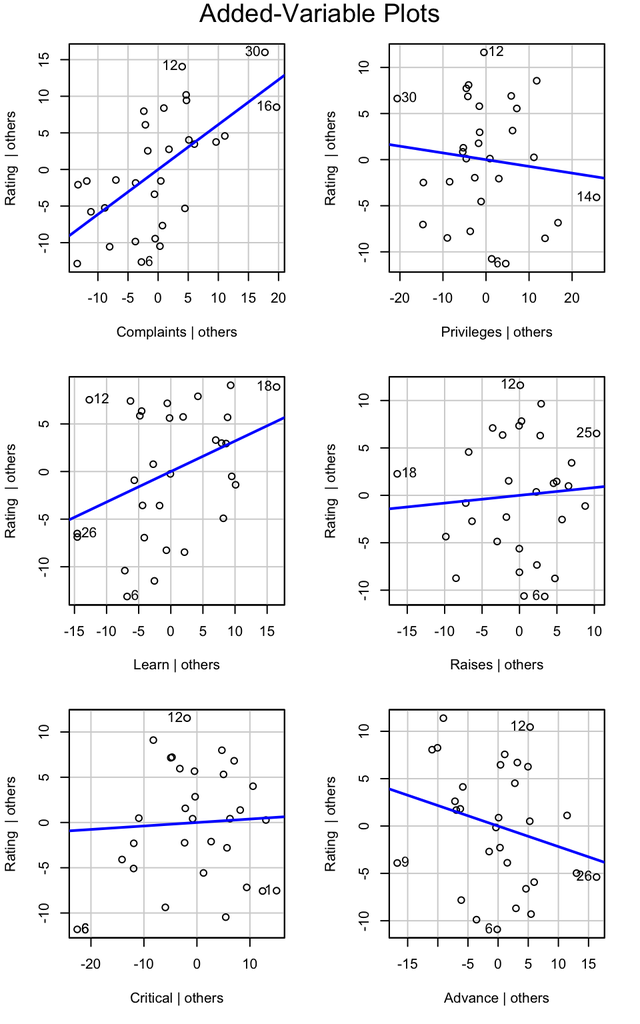

```r
avPlots(super.lm)
```

## Check Multiple Linear Regression Model Assumptions

### 1. The x’s vs y are linear

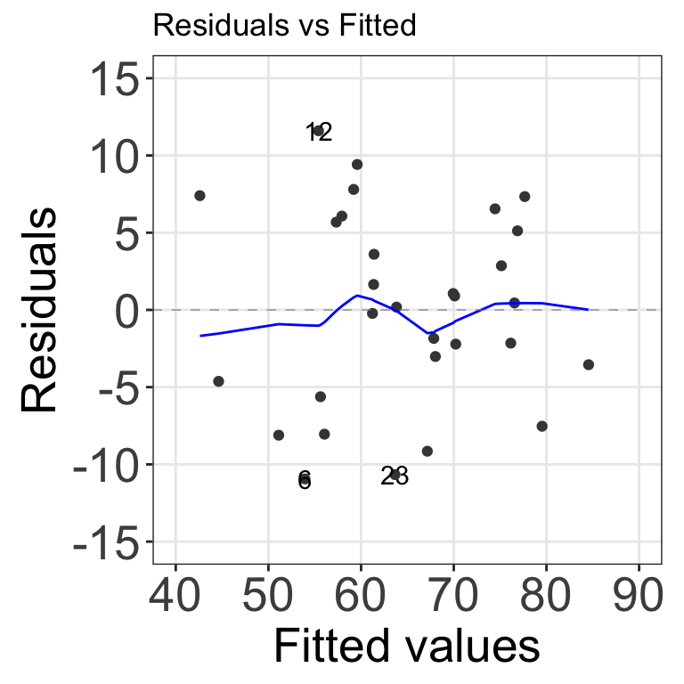

```r
sz <- 20
# plot(mod, which = 1)  # base R
autoplot(super.lm, which = 1, ncol = 1, nrow = 1) +
  theme_bw() +
  scale_y_continuous(limits = c(-15, 15),
                     labels = seq(-15, 15, by = 5),
                     breaks = seq(-15, 15, by = 5),
                     minor_breaks = seq(-15, 15, by = 5)) +
  scale_x_continuous(limits = c(40, 90),
                     labels = seq(40, 90, by = 10),
                     breaks = seq(40, 90, by = 10),
                     minor_breaks = seq(40, 90, by = 10)) +
  theme(axis.title.x = element_text(size = sz),
        axis.title.y = element_text(size = sz),
        axis.text = element_text(size = sz),
        aspect.ratio = 1)
```

### 2. The errors have constant variance

Check the Scale-location plot.

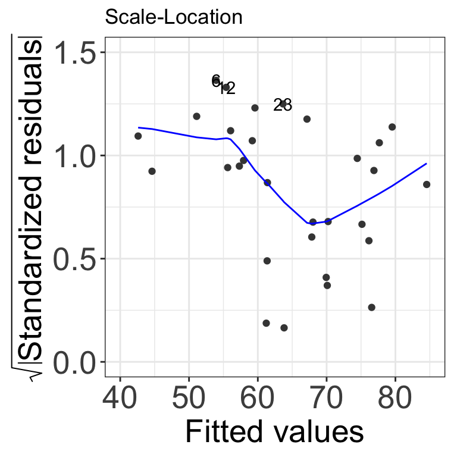

```r
autoplot(super.lm, which = 3, ncol = 1, nrow = 1) +
  theme_bw() +
  scale_y_continuous(limits = c(0, 1.5)) +
  scale_x_continuous(limits = c(40, 85)) +
  theme(axis.title.x = element_text(size = sz),
        axis.title.y = element_text(size = sz),
        axis.text = element_text(size = sz),
        aspect.ratio = 1)
```

### 3. The errors are independent.

You do not need to do anything for this assumption, as it is typically assessed by considering the way in which the data were sampled. However, this assumption should always be considered in linear regression.

### 4. The errors are normally distributed and centered at zero

**(a) Boxplot**

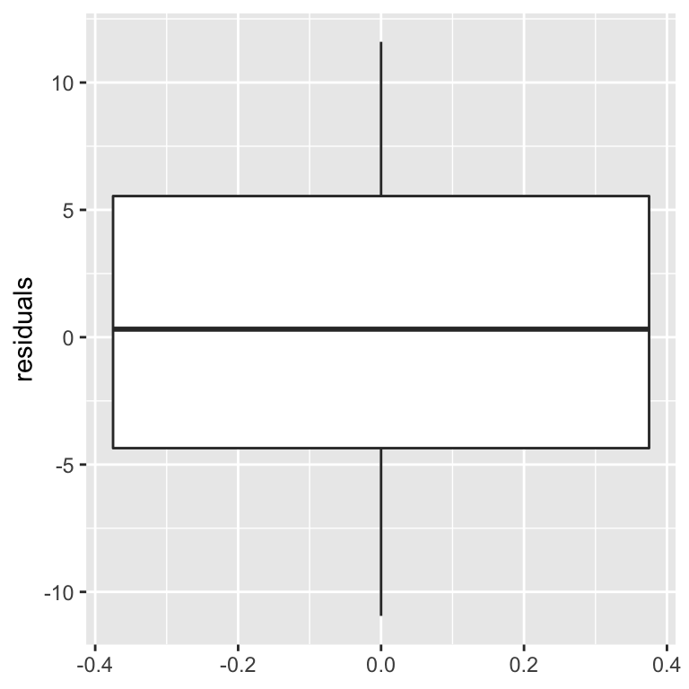

```r
ggplot(data = super, mapping = aes(y = residuals)) +
  geom_boxplot()
```

**(b) Histogram**

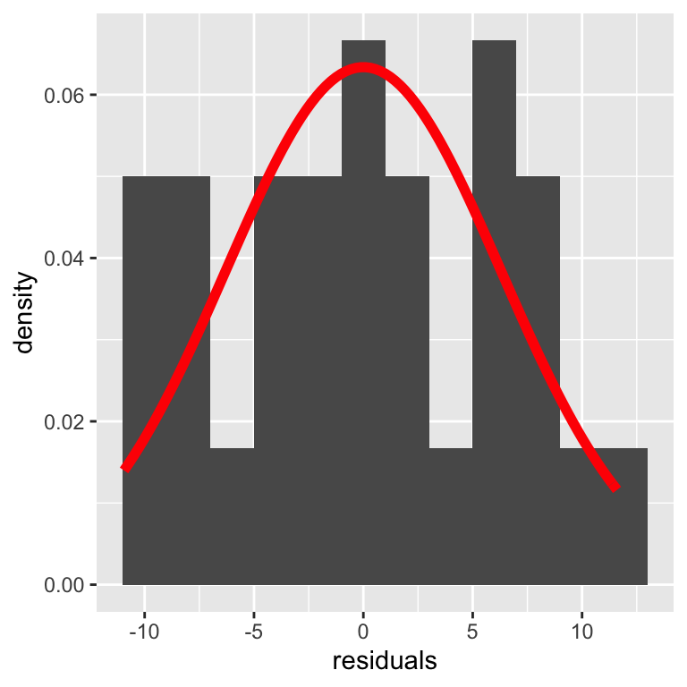

```r
ggplot(data = super, mapping = aes(x = residuals)) +
  geom_histogram(mapping = aes(y = ..density..), binwidth = 2) +
  stat_function(fun = dnorm, color = "red", size = 2,
                args = list(mean = mean(super$residuals),
                            sd = sd(super$residuals)))
```

**(c) Normal Probability Plot**

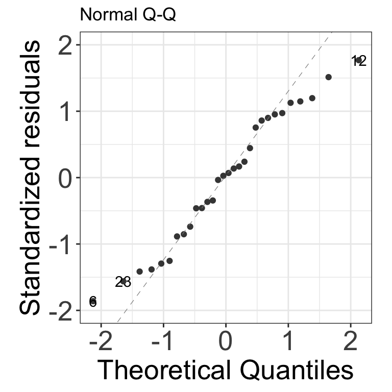

```r
autoplot(super.lm, which = 2, ncol = 1, nrow = 1)  +
  theme_bw() +
  scale_y_continuous(limits = c(-2, 2)) +
  theme(axis.title.x = element_text(size = sz),
        axis.title.y = element_text(size = sz),
        axis.text = element_text(size = sz),
        aspect.ratio = 1)
```

The assumptions seem to be *roughly* met, although it may be worthwhile to consider transformations, likely of the response variable since there are potentially issues with equal variance/normality. Another possibility would be to consider **interactions** between predictors, which we will discuss in future modules. For now, we will proceed to do inference with this model.

## Confidence Intervals/Bands

### Obtain confidence intervals for the slope coefficients in the model using `confint’. Convert these into simultaneous confidence intervals using either the Bonferonni or Scheffe method. Review (perhaps with someone sitting near you) the difference between the ordinary and simultaneous intervals.

```r
p <- ncol(super) - 1 # number of predictors
confint(super.lm, parm = 2:(p + 1))
```

```
##                  2.5 %    97.5 %
## Complaints  0.28016866 0.9462066
## Privileges -0.35381806 0.2077178
## Learn      -0.02827872 0.6689430
## Raises     -0.37642935 0.5398936
## Critical   -0.26570179 0.3424647
## Advance    -0.58571106 0.1515977
## <NA>                NA        NA
## <NA>                NA        NA
```

```r
tbon <- qt(1 - 0.05/(2*p), nrow(super) - p - 1)
schef <- sqrt(6*qf(1 - 0.05, p + 1, nrow(super) - p - 1))
mult <- min(tbon, schef) # take smaller of the two

SimCIbetas <- cbind(super.lm$coefficients[-1] - mult*summary(super.lm)$coefficients[-1, 2],
                    super.lm$coefficients[-1] + mult*summary(super.lm)$coefficients[-1, 2])
SimCIbetas
```

```
##                  [,1]      [,2]
## Complaints  0.1240813 1.1022939
## Privileges -0.4854151 0.3393149
## Learn      -0.1916741 0.8323383
## Raises     -0.5911715 0.7546358
## Critical   -0.4082269 0.4849898
## Advance    -0.7585009 0.3243875
```

The intervals provided by `confint’ are to be interpreted separately; for each one, we can say that it contains the true slope coefficient for the predictor with 95% confidence. For the simultaneous intervals, we can say with 95% confidence that **all** of the intervals contain their true parameter value.

### Create an effects plot for the `Complaints’ predictor, setting all other predictors to their median value. Add a 90% simultaneous confidence band to this plot, and review (again, perhaps with a neighbor) the meaning of this band.

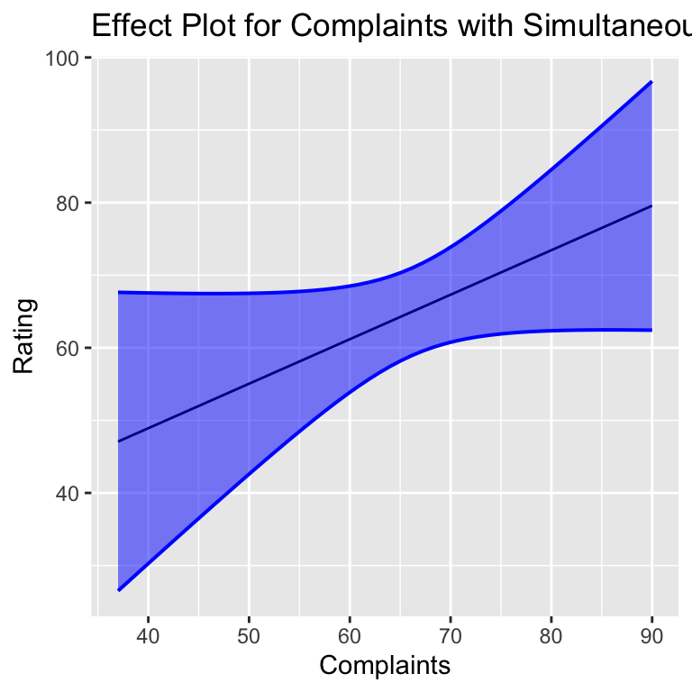

```r
comp.grid <- with(super, seq(min(Complaints), max(Complaints), length.out = 50))
comp.df <- with(super, data.frame(Complaints = comp.grid,
                                  Privileges = rep(median(Privileges), length(comp.grid)),
                                  Learn = rep(median(Learn), length(comp.grid)),
                                  Raises = rep(median(Raises), length(comp.grid)),
                                  Critical = rep(median(Critical), length(comp.grid)),
                                  Advance = rep(median(Advance), length(comp.grid))))
CBvals <- predict(super.lm, newdata = comp.df, se.fit = TRUE)

sim.mult <- sqrt((p + 1)*qf(0.9, p + 1, nrow(super) - p - 1))
comp.df$fit <- CBvals$fit
comp.df$SCBlow <- CBvals$fit - sim.mult*CBvals$se.fit
comp.df$SCBhi <- CBvals$fit + sim.mult*CBvals$se.fit

ComplaintsEffectPlot <- ggplot(data = comp.df) +
  geom_line(mapping = aes(x = Complaints, y = fit), color = 'black') +
  geom_line(mapping = aes(x = Complaints, y = SCBlow), color = 'blue', size = 0.7) +
  geom_line(mapping = aes(x = Complaints, y = SCBhi), color = 'blue', size = 0.7) +
  geom_ribbon(aes(ymin = SCBlow, ymax = SCBhi, x = Complaints), fill = 'blue', alpha = 0.5) +
  labs(title = "Effect Plot for Complaints with Simultaneous Confidence Band",
       x = "Complaints", y = "Rating")
ComplaintsEffectPlot
```

## Hypothesis testing

### Examine the summary output of your multiple linear regression model. Carefully interpret the following values:

**(a) The p-value of 0.000903 for the `Complaints’ predictor**

Once the effects of the other scores (Privileges, Learn, Raises, Critical, and Advance) have been controlled for, the Complaints score still has a highly significant effect on the average rating of a supervisor.

**(b) The p-value of 0.71548 for the `Raises’ predictor**

Although higher ratings are associated with higher Raises scores, once the other scores are controlled for, Raises no longer has an effect on average ratings.

**(c) The p-value of 1.24e-05 for the global F-test (last line of the output)**

At least one of the predictors has a significant linear effect on average supervisor ratings.

**(d) The Multiple R-squared value of 0.7326**

73.26% of the variability in this sample of supervisor ratings can be explained by a linear relationship with the surveyed scores.

### Verify (using a partial F-test) that, once the effect of `Complaints’ is included, all of the other predictors have estimated effects that are not statistically significantly different from zero. Explain (perhaps just verbally to a classmate) why it would be incorrect to draw this conclusion just because none of the individual effect p-values in the summary output are below 0.05.

```r
super.lm0 <- lm(Rating ~ Complaints, data = super)
anova(super.lm0, super.lm)
```

```
## Analysis of Variance Table
##
## Model 1: Rating ~ Complaints
## Model 2: Rating ~ Complaints + Privileges + Learn + Raises + Critical +
##     Advance
##   Res.Df    RSS Df Sum of Sq      F Pr(>F)
## 1     28 1369.4
## 2     23 1149.0  5    220.38 0.8823 0.5086
```

The statement is that, after only controlling for `Complaints’, none of the others are significant. In other words, we want to compare the model with *only* the Complaints score to the model involving all scores. However, the individual effect p-values do not test this. For example, the p-value for Learn is comparing the model with all score *except* Learn (the reduced model) to the model with all scores.

## Summary and Conclusions

Although several of the scores seem to be associated with a supervisor’s overall rating, the moderate to high correlations between scores indicate that not all of the scores are equally important in the regression model. This is confirmed by the added variable plots as well as statistical insignificance of many of the effects, which we have some confidence in after assessing the model assumptions using our diagnostic tools. Overall, it appears that `Complaints’ is the key variable that influences a supervisor’s average rating, with higher scores (indicative of better perception of the supervisor’s handling of complaints) leading to higher average ratings.